# Mixed ANOVA + Pairwise Comparison

5/7/2021

# Description

**Source of motivation: [Mixed ANOVA in R](https://www.datanovia.com/en/lessons/mixed-anova-in-r)** **Adapted from Ruslan Klymentiev RAnovas_main.R for the same project**

## Assumptions Check

**Outliers**. Values above `Q3 + 1.5xIQR` or below `Q1 - 1.5xIQR` are considered as outliers. Values above `Q3 + 3xIQR` or below `Q1 - 3xIQR` are considered as extreme points (or extreme outliers). Observations that are considered as extreme points are marked red.

**Normality Assumptions**. Plot shows Q-Q plot for subsets of data. If points lie on the line, we can assume that data is fairly symmetrical (and that’s what we want).

**Homogeneity of Variance Assumption**. Performed using [Levene’s test](https://en.wikipedia.org/wiki/Levene%27s_test).

$H_0$: the groups have equal population variances $H_A$: the groups don’t have equal population variances Observations with p-value < 0.05 are marked red, since they may violate the ANOVA results.

## Mixed ANOVA

“*In statistics, a mixed-design analysis of variance model, also known as a split-plot ANOVA, is used to test for differences between two or more independent groups whilst subjecting participants to repeated measures.*” ([Wikipedia](https://en.wikipedia.org/wiki/Mixed-design_analysis_of_variance))

within subjects group (with repeated measures): `Measurement` between subjects group: `Group`

## Post-hoc Tests

**Significant two-way interaction**. Can be used if an interaction term in Mixed ANOVA results showed significance. In other words, impact of `Group` on the outcome variable (`VectorStrength`) depends on the `Measurement` (and vice versa)

**Effect of `Group` at each `Measurement`**. Shows the **simple main effect** of the `Group`

**Pairwise comparisons between `Group`**. Performs [Welch’s t-tests](https://en.wikipedia.org/wiki/Welch%27s_t-test) (for unequal variances) for comparing `Group` for each `Measurement`

**Effect of `Measurement` at each level of `Group`**. Shows the **simple main effect** of the **`Measurement`**

**Pairwise comparisons between `Measurement`**. Performs **paired** two-sample t-test for comparing `Measurement` for each `Group`.

**Non-significant two-way interaction**. Shows the **main effect** for `Group` and `Measurement`. Used if there was non-significant two-way interaction.

For each table observations with adjusted p-value (using Bonferroni correction) which is less then 0.05 are marked green.

```r
library(tidyverse)
library(ggpubr)
library(rstatix)
library(knitr)
library(kableExtra)
```

```r
raw_data <- read_csv("D:/DynamicCSDjl/Data/VSoutput/AM_10_VectorStrength_Stats.csv")
data_type <- "AM"

layers <- unique(raw_data$Layer)
stimfreq <- 5
metrics <- c("VectorStrenght")

red_color <- "#ffb3b3"
green_color <- "#d6f5d6"

# values for testing
freq <- 5
layer <- "All"
metric <- "VectorStrenght"
```

# Results

```r
for (layer in layers){
  # for (layer in c("All", "I_II")){
  cat("###", layer, " Layer {.tabset .tabset-fade .tabset-pills}\n")

  model_data <- raw_data %>%
    filter(
      Layer == layer)

  model_data <- model_data %>%
    select(Group, Animal, Measurement, VectorStrenght)

  if(grepl("CL", data_type)) {
    model_data <- model_data %>%
      convert_as_factor(Group, Animal, Measurement) %>%
      reorder_levels(
        Measurement,
        order = c("preCL_1", "CL_1", "CL_2", "CL_3", "CL_4"))
  } else {
    model_data <- model_data %>%
      filter(Measurement != "AM_5") %>%
      reorder_levels(
        Measurement,
        order = c("preAM_1", "AM_1", "AM_2", "AM_3", "AM_4"))
  }

  cat("####", metric, "{.tabset .tabset-fade .tabset-pills}\n")

  cat("##### Assumptions Check\n")

  cat("<b>===OUTLIERS===</b>\n\n")

  df <- model_data %>%
    group_by(Measurement, Group) %>%
    identify_outliers(eval(metric))

  if(nrow(df) > 0){
    df %>%
      kable(escape = F, digits = 6) %>%
      kable_classic_2(full_width = F) %>%
      kable_styling() %>%
      row_spec(
        which(df$is.extreme == TRUE), bold = T,
        background = red_color) %>%
      print()
  } else{
    cat("\n\nNo outliers were detected.\n\n")
  }

  cat("\n\n<b>===NORMALITY ASSUMPTION===</b>\n\n")

  p <- ggqqplot(model_data, metric, ggtheme = theme_bw()) +
    facet_grid(Measurement ~ Group)
  plot(p)

  cat("\n\n<b>===HOMOGENEITY OF VARIANCE ASSUMPTION===</b>\n\n")

  df <- model_data %>%
    group_by(Measurement) %>%
    levene_test(formula = as.formula(paste0(metric, "~ Group")))

  df %>%
    kable(escape = F, digits = 3) %>%
    kable_classic_2(full_width = F) %>%
    kable_styling() %>%
    row_spec(
      which(df$p <= 0.05), bold = T,
      background = red_color) %>%
    print()

  cat('\n\n')

  cat("##### Mixed ANOVA\n")

  # Two-way mixed ANOVA test
  res.aov <- anova_test(
    data = model_data, dv = eval(metric), wid = Animal,
    between = Group, within = Measurement)

  df <- get_anova_table(res.aov) %>%
    data.frame()

  df %>%
    kable(escape = F) %>%
    kable_classic_2(full_width = F) %>%
    kable_styling() %>%
    row_spec(
      which(df$p <= 0.05), bold = T,
      background = green_color) %>%
    print()

  cat('\n\n')

  cat("##### Post-hoc Tests\n")

  cat("\n\n<b>===SIGNIFICANT TWO-WAY INTERACTION===</b>\n\n")

  cat("\n\n\n<b>=EFFECT OF GROUP AT EACH MEASUREMENT=</b>\n\n")

  one.way <- model_data %>%
    group_by(Measurement) %>%
    anova_test(dv = eval(metric), wid = Animal, between = Group) %>%
    get_anova_table() %>%
    adjust_pvalue(method = "bonferroni")

  df <- one.way %>%
    data.frame() %>%
    select(-F)
  df %>%
    kable(escape = F) %>%
    kable_classic_2(full_width = F) %>%
    kable_styling() %>%
    row_spec(
      which(df$p.adj <= 0.05), bold = T,
      background = green_color) %>%
    print()

  cat("\n\n\n<b>=PAIRWISE COMPARISONS BETWEEN GROUP LEVELS=</b>\n\n")

  pwc <- model_data %>%
    group_by(Measurement) %>%
    pairwise_t_test(
      as.formula(paste0(metric, "~ Group")),
      p.adjust.method = "bonferroni",
      pool.sd = FALSE,
      var.equal = FALSE)

  eff_size <- model_data %>%
    group_by(Measurement) %>%
    cohens_d(
      as.formula(paste0(metric, "~ Group")),
      var.equal = FALSE)

  df <- pwc %>%
    left_join(eff_size) %>%
    data.frame()

  df %>%
    kable(escape = F, digits = 3) %>%
    kable_classic_2(full_width = F) %>%
    kable_styling() %>%
    row_spec(
      which(df$p.adj <= 0.05), bold = T,
      background = green_color) %>%
    print()

  cat("\n\n\n<b>=EFFECT OF MEASUREMENT AT EACH LEVEL OF GROUP=</b>\n\n")

  one.way2 <- model_data %>%
    group_by(Group) %>%
    anova_test(dv = eval(metric), wid = Animal, within = Measurement) %>%
    get_anova_table() %>%
    adjust_pvalue(method = "bonferroni")

  df <- one.way2 %>%
    data.frame()
  df %>%
    kable(escape = F) %>%
    kable_classic_2(full_width = F) %>%
    kable_styling() %>%
    row_spec(
      which(df$p.adj <= 0.05), bold = T,
      background = green_color) %>%
    print()

  cat("\n\n\n<b>=PAIRWISE COMPARISONS BETWEEN MEASUREMENTS AT EACH GROUP LEVELS=</b>\n\n")

  exclude_animals <- model_data %>%
    group_by(Animal) %>%
    summarise(n = n_distinct(Measurement)) %>%
    filter(n < 5) %>%
    pull(Animal)

  pwc2 <- model_data %>%
    filter(!(Animal %in% exclude_animals)) %>%
    group_by(Group) %>%
    pairwise_t_test(
      as.formula(paste0(metric, "~ Measurement")),
      paired = TRUE,
      pool.sd = FALSE,
      var.equal = FALSE,
      p.adjust.method = "bonferroni"
    )

  eff_size2 <- model_data %>%
    filter(!(Animal %in% exclude_animals)) %>%
    group_by(Group) %>%
    cohens_d(
      as.formula(paste0(metric, "~ Measurement")),
      paired = TRUE,
      var.equal = FALSE)

  df <- pwc2 %>%
    left_join(eff_size2) %>%
    data.frame()
  df %>%
    kable(escape = F, digits = 3) %>%
    kable_classic_2(full_width = F) %>%
    kable_styling() %>%
    row_spec(
      which(df$p.adj <= 0.05), bold = T,
      background = green_color) %>%
    print()

  cat("\n\n\n<b>===NON-SIGNIFICANT TWO-WAY INTERACTION===</b>\n\n")
  cat("\n\n\n<b>=MAIN EFFECT OF MEASUREMENT=</b>\n\n")

  df <- model_data %>%
    filter(!(Animal %in% exclude_animals)) %>%
    pairwise_t_test(
      as.formula(paste0(metric, "~ Measurement")),
      paired = TRUE,
      p.adjust.method = "bonferroni"
    ) %>%
    data.frame()

  df %>%
    kable(escape = F) %>%
    kable_classic_2(full_width = F) %>%
    kable_styling() %>%
    row_spec(
      which(df$p.adj <= 0.05), bold = T,
      background = green_color) %>%
    print()

  cat("\n\n\n<b>=MAIN EFFECT OF GROUP=</b>\n\n")

  df <- model_data %>%
    pairwise_t_test(
      as.formula(paste0(metric, "~ Group")),
      p.adjust.method = "bonferroni"
    ) %>%
    data.frame()

  df %>%
    kable(escape = F) %>%
    kable_classic_2(full_width = F) %>%
    kable_styling() %>%
    row_spec(
      which(df$p.adj <= 0.05), bold = T,
      background = green_color) %>%
    print()

  cat('\n\n')

  cat("##### Plots\n")

  pwc <- pwc %>% add_xy_position(x = "Measurement")
  pwc2 <- pwc2 %>% add_xy_position(x = "Group")

  box_plot <- ggboxplot(
    model_data, x = "Measurement", y = metric,
    color = "Group", palette = "jco"
  )

  box_plot2 <- ggboxplot(
    model_data, x = "Group", y = metric,
    color = "Measurement", palette = "jco"
  )

  p <- box_plot +
    stat_pvalue_manual(pwc, tip.length = 0.01, hide.ns = TRUE) +
    labs(
      title = paste0(metric, " for ", layer, " Layer, ", freq, "Hz and 1st Click"),
      subtitle = get_test_label(res.aov, detailed = TRUE),
      caption = get_pwc_label(pwc)
    )

  plot(p)

  cat('\n\n')

  p <- box_plot2 +
    stat_pvalue_manual(pwc2, tip.length = 0.01, hide.ns = TRUE) +
    labs(
      title = paste0(metric, " for ", layer, " Layer, ", freq, "Hz and 1st Click"),
      subtitle = get_test_label(res.aov, detailed = TRUE),
      caption = get_pwc_label(pwc2)
    )

  plot(p)

  cat('\n\n')
}
```

### All Layer

#### VectorStrenght

##### Assumptions Check

**===OUTLIERS===**

| Group | Measurement | Animal | VectorStrenght | is.outlier | is.extreme |
| --- | --- | --- | --- | --- | --- |
| KIC | preAM_1 | KIC10 | 0.401348 | TRUE | FALSE |
| KIT | AM_1 | KIT01 | 0.172466 | TRUE | FALSE |
| KIT | AM_1 | KIT03 | 0.349682 | TRUE | FALSE |
| KIT | AM_1 | KIT09 | 0.368876 | TRUE | FALSE |
| KIC | AM_2 | KIC10 | 0.336338 | TRUE | TRUE |
| KIC | AM_2 | KIC14 | 0.344465 | TRUE | TRUE |
| KIV | AM_2 | KIV12 | 0.360626 | TRUE | FALSE |
| KIV | AM_4 | KIV09 | 0.188843 | TRUE | TRUE |

**===NORMALITY ASSUMPTION===**

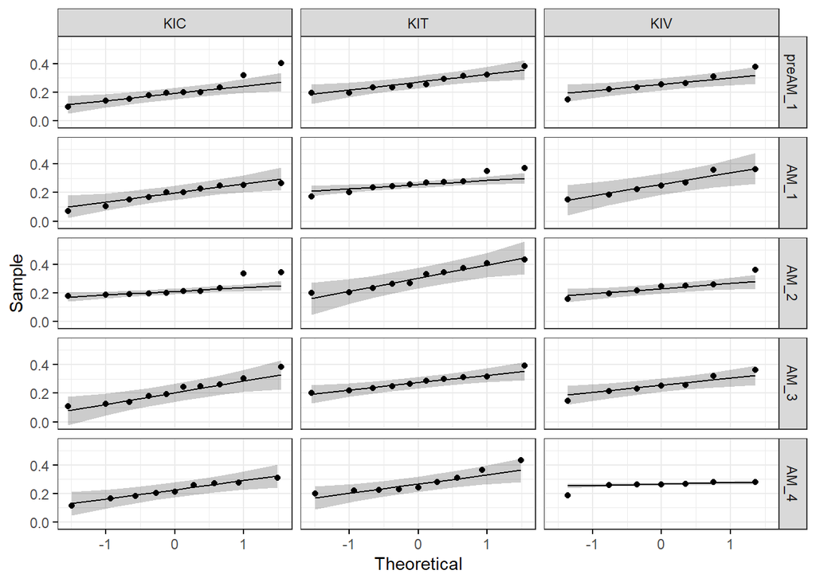

**===HOMOGENEITY OF VARIANCE ASSUMPTION===**

| Measurement | df1 | df2 | statistic | p |
| --- | --- | --- | --- | --- |
| preAM_1 | 2 | 24 | 0.168 | 0.847 |
| AM_1 | 2 | 24 | 0.378 | 0.689 |
| AM_2 | 2 | 24 | 1.563 | 0.230 |
| AM_3 | 2 | 24 | 1.015 | 0.378 |
| AM_4 | 2 | 22 | 1.703 | 0.205 |

##### Mixed ANOVA

Effect

DFn

DFd

F

p

p..05

ges

Group

2

22

3.887

0.036

0.156

Measurement

4

88

0.867

0.487

0.018

Group:Measurement

8

88

0.620

0.759

0.026

##### Post-hoc Tests

**===SIGNIFICANT TWO-WAY INTERACTION===**

**=EFFECT OF GROUP AT EACH MEASUREMENT=**

Measurement

Effect

DFn

DFd

p

p..05

ges

p.adj

preAM_1

Group

2

24

0.241

0.112

1.000

AM_1

Group

2

24

0.041

0.233

0.205

AM_2

Group

2

24

0.058

0.211

0.290

AM_3

Group

2

24

0.199

0.126

0.995

AM_4

Group

2

22

0.170

0.149

0.850

**=PAIRWISE COMPARISONS BETWEEN GROUP LEVELS=**

Measurement

.y.

group1

group2

n1

n2

statistic

df

p

p.adj

p.adj.signif

effsize

magnitude

preAM_1

VectorStrenght

KIC

KIT

10

10

-1.623

15.810

0.124

0.372

ns

-0.726

moderate

preAM_1

VectorStrenght

KIC

KIV

10

7

-1.177

14.606

0.258

0.774

ns

-0.569

moderate

preAM_1

VectorStrenght

KIT

KIV

10

7

0.277

11.524

0.786

1.000

ns

0.139

negligible

AM_1

VectorStrenght

KIC

KIT

10

10

-2.711

17.900

0.014

0.043

-1.213

large

AM_1

VectorStrenght

KIC

KIV

10

7

-1.833

11.177

0.094

0.280

ns

-0.920

large

AM_1

VectorStrenght

KIT

KIV

10

7

0.243

10.556

0.813

1.000

ns

0.123

negligible

AM_2

VectorStrenght

KIC

KIT

10

10

-2.318

16.411

0.034

0.101

ns

-1.037

large

AM_2

VectorStrenght

KIC

KIV

10

7

-0.355

12.533

0.728

1.000

ns

-0.176

negligible

AM_2

VectorStrenght

KIT

KIV

10

7

1.800

14.787

0.092

0.277

ns

0.867

large

AM_3

VectorStrenght

KIC

KIT

10

10

-1.834

15.460

0.086

0.258

ns

-0.820

large

AM_3

VectorStrenght

KIC

KIV

10

7

-0.962

14.504

0.352

1.000

ns

-0.466

small

AM_3

VectorStrenght

KIT

KIV

10

7

0.713

11.014

0.491

1.000

ns

0.358

small

AM_4

VectorStrenght

KIC

KIT

9

9

-1.717

15.198

0.106

0.318

ns

-0.810

large

AM_4

VectorStrenght

KIC

KIV

9

7

-1.506

12.382

0.157

0.471

ns

-0.731

moderate

AM_4

VectorStrenght

KIT

KIV

9

7

0.740

11.043

0.475

1.000

ns

0.356

small

**=EFFECT OF MEASUREMENT AT EACH LEVEL OF GROUP=**

| Group | Effect | DFn | DFd | F | p | p..05 | ges | p.adj |
| --- | --- | --- | --- | --- | --- | --- | --- | --- |
| KIC | Measurement | 4 | 32 | 0.805 | 0.531 |  | 0.051 | 1 |
| KIT | Measurement | 4 | 32 | 1.159 | 0.347 |  | 0.069 | 1 |
| KIV | Measurement | 4 | 24 | 0.212 | 0.929 |  | 0.011 | 1 |

**=PAIRWISE COMPARISONS BETWEEN MEASUREMENTS AT EACH GROUP LEVELS=**

| Group | .y. | group1 | group2 | n1 | n2 | statistic | df | p | p.adj | p.adj.signif | effsize | magnitude |
| --- | --- | --- | --- | --- | --- | --- | --- | --- | --- | --- | --- | --- |
| KIC | VectorStrenght | preAM_1 | AM_1 | 9 | 9 | 1.008 | 8 | 0.343 | 1.000 | ns | 0.336 | small |
| KIC | VectorStrenght | preAM_1 | AM_2 | 9 | 9 | -0.798 | 8 | 0.448 | 1.000 | ns | -0.266 | small |
| KIC | VectorStrenght | preAM_1 | AM_3 | 9 | 9 | -0.349 | 8 | 0.736 | 1.000 | ns | -0.116 | negligible |
| KIC | VectorStrenght | preAM_1 | AM_4 | 9 | 9 | -0.173 | 8 | 0.867 | 1.000 | ns | -0.058 | negligible |
| KIC | VectorStrenght | AM_1 | AM_2 | 9 | 9 | -2.036 | 8 | 0.076 | 0.761 | ns | -0.679 | moderate |
| KIC | VectorStrenght | AM_1 | AM_3 | 9 | 9 | -1.294 | 8 | 0.232 | 1.000 | ns | -0.431 | small |
| KIC | VectorStrenght | AM_1 | AM_4 | 9 | 9 | -1.203 | 8 | 0.263 | 1.000 | ns | -0.401 | small |
| KIC | VectorStrenght | AM_2 | AM_3 | 9 | 9 | 0.095 | 8 | 0.927 | 1.000 | ns | 0.032 | negligible |
| KIC | VectorStrenght | AM_2 | AM_4 | 9 | 9 | 0.656 | 8 | 0.530 | 1.000 | ns | 0.219 | small |
| KIC | VectorStrenght | AM_3 | AM_4 | 9 | 9 | 0.383 | 8 | 0.712 | 1.000 | ns | 0.128 | negligible |
| KIT | VectorStrenght | preAM_1 | AM_1 | 9 | 9 | 0.463 | 8 | 0.656 | 1.000 | ns | 0.154 | negligible |
| KIT | VectorStrenght | preAM_1 | AM_2 | 9 | 9 | -1.473 | 8 | 0.179 | 1.000 | ns | -0.491 | small |
| KIT | VectorStrenght | preAM_1 | AM_3 | 9 | 9 | -0.340 | 8 | 0.743 | 1.000 | ns | -0.113 | negligible |
| KIT | VectorStrenght | preAM_1 | AM_4 | 9 | 9 | -0.207 | 8 | 0.841 | 1.000 | ns | -0.069 | negligible |
| KIT | VectorStrenght | AM_1 | AM_2 | 9 | 9 | -1.941 | 8 | 0.088 | 0.883 | ns | -0.647 | moderate |
| KIT | VectorStrenght | AM_1 | AM_3 | 9 | 9 | -0.759 | 8 | 0.470 | 1.000 | ns | -0.253 | small |
| KIT | VectorStrenght | AM_1 | AM_4 | 9 | 9 | -0.498 | 8 | 0.632 | 1.000 | ns | -0.166 | negligible |
| KIT | VectorStrenght | AM_2 | AM_3 | 9 | 9 | 1.235 | 8 | 0.252 | 1.000 | ns | 0.412 | small |
| KIT | VectorStrenght | AM_2 | AM_4 | 9 | 9 | 1.633 | 8 | 0.141 | 1.000 | ns | 0.544 | moderate |
| KIT | VectorStrenght | AM_3 | AM_4 | 9 | 9 | 0.177 | 8 | 0.864 | 1.000 | ns | 0.059 | negligible |
| KIV | VectorStrenght | preAM_1 | AM_1 | 7 | 7 | 0.091 | 6 | 0.930 | 1.000 | ns | 0.035 | negligible |
| KIV | VectorStrenght | preAM_1 | AM_2 | 7 | 7 | 1.915 | 6 | 0.104 | 1.000 | ns | 0.724 | moderate |
| KIV | VectorStrenght | preAM_1 | AM_3 | 7 | 7 | 0.250 | 6 | 0.811 | 1.000 | ns | 0.094 | negligible |
| KIV | VectorStrenght | preAM_1 | AM_4 | 7 | 7 | 0.019 | 6 | 0.985 | 1.000 | ns | 0.007 | negligible |
| KIV | VectorStrenght | AM_1 | AM_2 | 7 | 7 | 0.583 | 6 | 0.581 | 1.000 | ns | 0.220 | small |
| KIV | VectorStrenght | AM_1 | AM_3 | 7 | 7 | 0.030 | 6 | 0.977 | 1.000 | ns | 0.011 | negligible |
| KIV | VectorStrenght | AM_1 | AM_4 | 7 | 7 | -0.053 | 6 | 0.959 | 1.000 | ns | -0.020 | negligible |
| KIV | VectorStrenght | AM_2 | AM_3 | 7 | 7 | -0.781 | 6 | 0.464 | 1.000 | ns | -0.295 | small |
| KIV | VectorStrenght | AM_2 | AM_4 | 7 | 7 | -0.819 | 6 | 0.444 | 1.000 | ns | -0.310 | small |
| KIV | VectorStrenght | AM_3 | AM_4 | 7 | 7 | -0.114 | 6 | 0.913 | 1.000 | ns | -0.043 | negligible |

**===NON-SIGNIFICANT TWO-WAY INTERACTION===**

**=MAIN EFFECT OF MEASUREMENT=**

| .y. | group1 | group2 | n1 | n2 | statistic | df | p | p.adj | p.adj.signif |
| --- | --- | --- | --- | --- | --- | --- | --- | --- | --- |
| VectorStrenght | preAM_1 | AM_1 | 25 | 25 | 1.0271907 | 24 | 0.315 | 1.000 | ns |
| VectorStrenght | preAM_1 | AM_2 | 25 | 25 | -1.2137518 | 24 | 0.237 | 1.000 | ns |
| VectorStrenght | preAM_1 | AM_3 | 25 | 25 | -0.4398553 | 24 | 0.664 | 1.000 | ns |
| VectorStrenght | preAM_1 | AM_4 | 25 | 25 | -0.2239480 | 24 | 0.825 | 1.000 | ns |
| VectorStrenght | AM_1 | AM_2 | 25 | 25 | -2.0435402 | 24 | 0.052 | 0.521 | ns |
| VectorStrenght | AM_1 | AM_3 | 25 | 25 | -1.3770288 | 24 | 0.181 | 1.000 | ns |
| VectorStrenght | AM_1 | AM_4 | 25 | 25 | -1.0730786 | 24 | 0.294 | 1.000 | ns |
| VectorStrenght | AM_2 | AM_3 | 25 | 25 | 0.5730026 | 24 | 0.572 | 1.000 | ns |
| VectorStrenght | AM_2 | AM_4 | 25 | 25 | 1.0603139 | 24 | 0.300 | 1.000 | ns |
| VectorStrenght | AM_3 | AM_4 | 25 | 25 | 0.3008841 | 24 | 0.766 | 1.000 | ns |

**=MAIN EFFECT OF GROUP=**

.y.

group1

group2

n1

n2

p

p.signif

p.adj

p.adj.signif

VectorStrenght

KIC

KIT

49

49

5.70e-06

0.000017

VectorStrenght

KIC

KIV

49

35

9.46e-03

0.028400

VectorStrenght

KIT

KIV

49

35

9.39e-02

ns

0.282000

ns

##### Plots

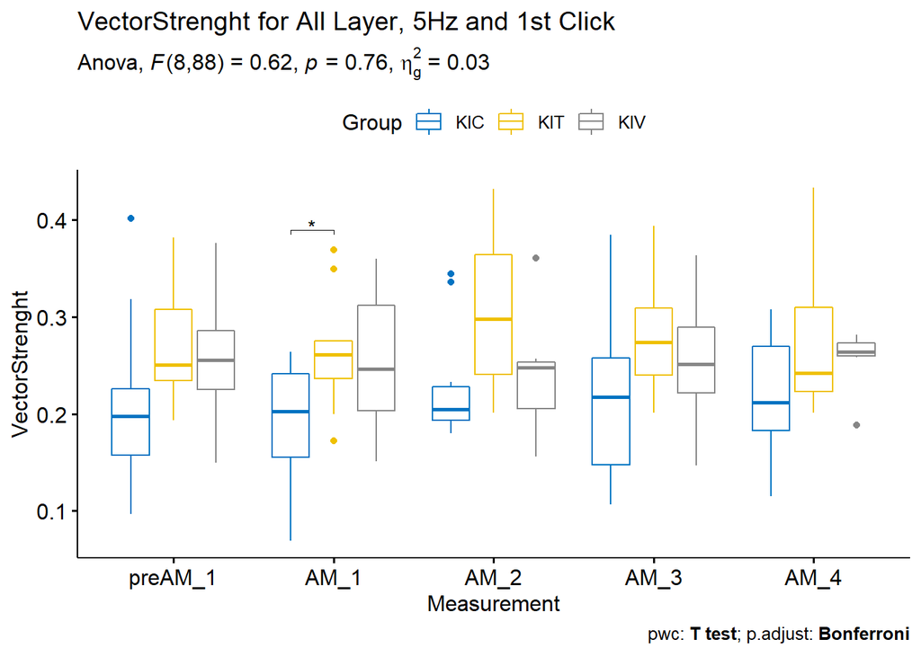

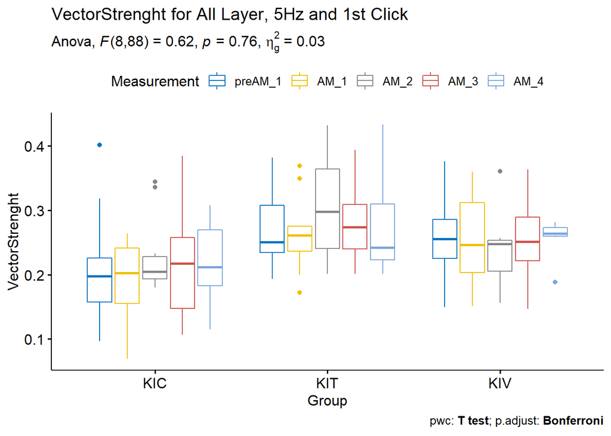

### I_II Layer

#### VectorStrenght

##### Assumptions Check

**===OUTLIERS===**

| Group | Measurement | Animal | VectorStrenght | is.outlier | is.extreme |
| --- | --- | --- | --- | --- | --- |
| KIC | AM_1 | KIC14 | 0.218909 | TRUE | FALSE |

**===NORMALITY ASSUMPTION===**

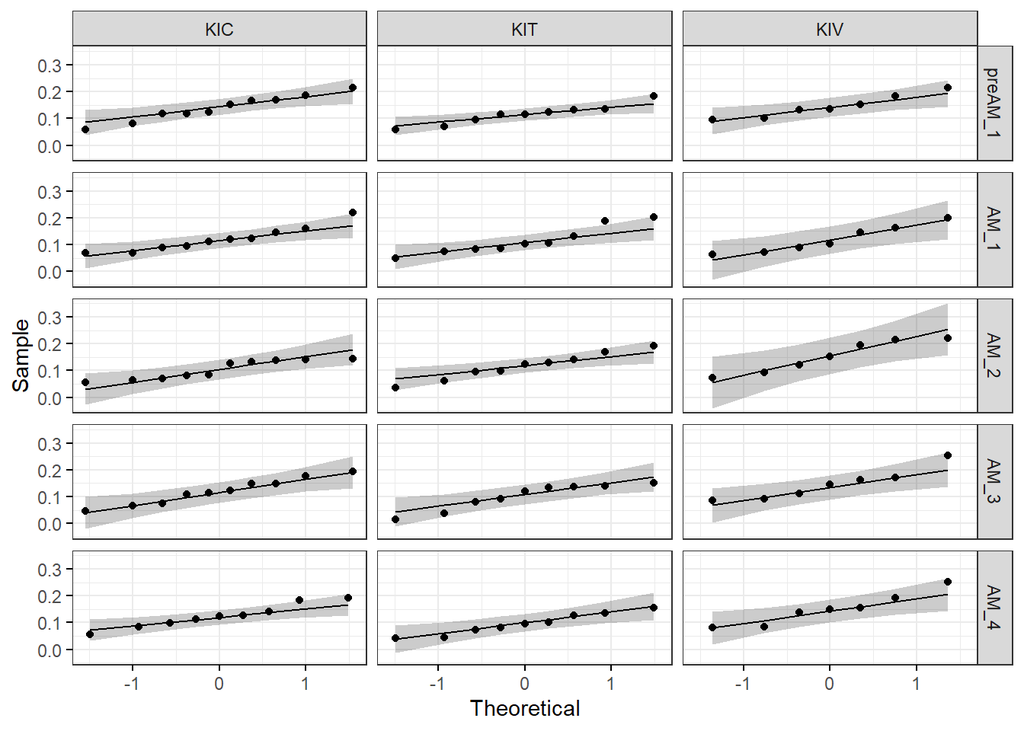

**===HOMOGENEITY OF VARIANCE ASSUMPTION===**

| Measurement | df1 | df2 | statistic | p |
| --- | --- | --- | --- | --- |
| preAM_1 | 2 | 23 | 0.559 | 0.579 |
| AM_1 | 2 | 23 | 0.111 | 0.896 |
| AM_2 | 2 | 23 | 1.052 | 0.366 |
| AM_3 | 2 | 23 | 0.065 | 0.937 |
| AM_4 | 2 | 22 | 0.301 | 0.743 |

##### Mixed ANOVA

| Effect | DFn | DFd | F | p | p..05 | ges |
| --- | --- | --- | --- | --- | --- | --- |
| Group | 2 | 22 | 1.584 | 0.228 |  | 0.090 |
| Measurement | 4 | 88 | 0.588 | 0.672 |  | 0.008 |
| Group:Measurement | 8 | 88 | 1.618 | 0.131 |  | 0.044 |

##### Post-hoc Tests

**===SIGNIFICANT TWO-WAY INTERACTION===**

**=EFFECT OF GROUP AT EACH MEASUREMENT=**

| Measurement | Effect | DFn | DFd | p | p..05 | ges | p.adj |
| --- | --- | --- | --- | --- | --- | --- | --- |
| preAM_1 | Group | 2 | 23 | 0.321 |  | 0.094 | 1.00 |
| AM_1 | Group | 2 | 23 | 0.957 |  | 0.004 | 1.00 |
| AM_2 | Group | 2 | 23 | 0.130 |  | 0.163 | 0.65 |
| AM_3 | Group | 2 | 23 | 0.228 |  | 0.121 | 1.00 |
| AM_4 | Group | 2 | 22 | 0.084 |  | 0.202 | 0.42 |

**=PAIRWISE COMPARISONS BETWEEN GROUP LEVELS=**

| Measurement | .y. | group1 | group2 | n1 | n2 | statistic | df | p | p.adj | p.adj.signif | effsize | magnitude |
| --- | --- | --- | --- | --- | --- | --- | --- | --- | --- | --- | --- | --- |
| preAM_1 | VectorStrenght | KIC | KIT | 10 | 10 | 1.264 | 16.689 | 0.224 | 0.672 | ns | 0.577 | moderate |
| preAM_1 | VectorStrenght | KIC | KIV | 10 | 7 | -0.256 | 13.914 | 0.802 | 1.000 | ns | -0.125 | negligible |
| preAM_1 | VectorStrenght | KIT | KIV | 10 | 7 | -1.485 | 11.967 | 0.163 | 0.489 | ns | -0.755 | moderate |
| AM_1 | VectorStrenght | KIC | KIT | 10 | 10 | 0.284 | 16.188 | 0.780 | 1.000 | ns | 0.131 | negligible |
| AM_1 | VectorStrenght | KIC | KIV | 10 | 7 | 0.039 | 12.089 | 0.970 | 1.000 | ns | 0.019 | negligible |
| AM_1 | VectorStrenght | KIT | KIV | 10 | 7 | -0.211 | 13.067 | 0.836 | 1.000 | ns | -0.106 | negligible |
| AM_2 | VectorStrenght | KIC | KIT | 10 | 10 | -0.637 | 14.511 | 0.534 | 1.000 | ns | -0.295 | small |
| AM_2 | VectorStrenght | KIC | KIV | 10 | 7 | -1.940 | 9.056 | 0.084 | 0.252 | ns | -0.995 | large |
| AM_2 | VectorStrenght | KIT | KIV | 10 | 7 | -1.297 | 11.638 | 0.220 | 0.660 | ns | -0.661 | moderate |
| AM_3 | VectorStrenght | KIC | KIT | 10 | 10 | 0.864 | 16.750 | 0.400 | 1.000 | ns | 0.397 | small |
| AM_3 | VectorStrenght | KIC | KIV | 10 | 7 | -0.992 | 11.287 | 0.342 | 1.000 | ns | -0.497 | small |
| AM_3 | VectorStrenght | KIT | KIV | 10 | 7 | -1.670 | 11.613 | 0.122 | 0.366 | ns | -0.851 | large |
| AM_4 | VectorStrenght | KIC | KIT | 9 | 9 | 1.494 | 15.801 | 0.155 | 0.465 | ns | 0.704 | moderate |
| AM_4 | VectorStrenght | KIC | KIV | 9 | 7 | -0.980 | 10.804 | 0.348 | 1.000 | ns | -0.503 | moderate |
| AM_4 | VectorStrenght | KIT | KIV | 9 | 7 | -2.149 | 9.974 | 0.057 | 0.172 | ns | -1.109 | large |

**=EFFECT OF MEASUREMENT AT EACH LEVEL OF GROUP=**

| Group | Effect | DFn | DFd | F | p | p..05 | ges | p.adj |
| --- | --- | --- | --- | --- | --- | --- | --- | --- |
| KIC | Measurement | 4 | 32 | 1.275 | 0.300 |  | 0.062 | 0.900 |
| KIT | Measurement | 4 | 32 | 0.966 | 0.439 |  | 0.039 | 1.000 |
| KIV | Measurement | 4 | 24 | 1.623 | 0.201 |  | 0.055 | 0.603 |

**=PAIRWISE COMPARISONS BETWEEN MEASUREMENTS AT EACH GROUP LEVELS=**

| Group | .y. | group1 | group2 | n1 | n2 | statistic | df | p | p.adj | p.adj.signif | effsize | magnitude |
| --- | --- | --- | --- | --- | --- | --- | --- | --- | --- | --- | --- | --- |
| KIC | VectorStrenght | preAM_1 | AM_1 | 9 | 9 | 0.647 | 8 | 0.536 | 1.000 | ns | 0.216 | small |
| KIC | VectorStrenght | preAM_1 | AM_2 | 9 | 9 | 2.073 | 8 | 0.072 | 0.719 | ns | 0.691 | moderate |
| KIC | VectorStrenght | preAM_1 | AM_3 | 9 | 9 | 1.623 | 8 | 0.143 | 1.000 | ns | 0.541 | moderate |
| KIC | VectorStrenght | preAM_1 | AM_4 | 9 | 9 | 0.601 | 8 | 0.564 | 1.000 | ns | 0.200 | small |
| KIC | VectorStrenght | AM_1 | AM_2 | 9 | 9 | 0.938 | 8 | 0.376 | 1.000 | ns | 0.313 | small |
| KIC | VectorStrenght | AM_1 | AM_3 | 9 | 9 | 0.381 | 8 | 0.713 | 1.000 | ns | 0.127 | negligible |
| KIC | VectorStrenght | AM_1 | AM_4 | 9 | 9 | -0.191 | 8 | 0.853 | 1.000 | ns | -0.064 | negligible |
| KIC | VectorStrenght | AM_2 | AM_3 | 9 | 9 | -1.290 | 8 | 0.233 | 1.000 | ns | -0.430 | small |
| KIC | VectorStrenght | AM_2 | AM_4 | 9 | 9 | -2.912 | 8 | 0.020 | 0.195 | ns | -0.971 | large |
| KIC | VectorStrenght | AM_3 | AM_4 | 9 | 9 | -1.143 | 8 | 0.286 | 1.000 | ns | -0.381 | small |
| KIT | VectorStrenght | preAM_1 | AM_1 | 9 | 9 | 0.067 | 8 | 0.948 | 1.000 | ns | 0.022 | negligible |
| KIT | VectorStrenght | preAM_1 | AM_2 | 9 | 9 | -0.115 | 8 | 0.911 | 1.000 | ns | -0.038 | negligible |
| KIT | VectorStrenght | preAM_1 | AM_3 | 9 | 9 | 1.025 | 8 | 0.335 | 1.000 | ns | 0.342 | small |
| KIT | VectorStrenght | preAM_1 | AM_4 | 9 | 9 | 1.424 | 8 | 0.192 | 1.000 | ns | 0.475 | small |
| KIT | VectorStrenght | AM_1 | AM_2 | 9 | 9 | -0.223 | 8 | 0.829 | 1.000 | ns | -0.074 | negligible |
| KIT | VectorStrenght | AM_1 | AM_3 | 9 | 9 | 1.006 | 8 | 0.344 | 1.000 | ns | 0.335 | small |
| KIT | VectorStrenght | AM_1 | AM_4 | 9 | 9 | 1.564 | 8 | 0.157 | 1.000 | ns | 0.521 | moderate |
| KIT | VectorStrenght | AM_2 | AM_3 | 9 | 9 | 1.338 | 8 | 0.218 | 1.000 | ns | 0.446 | small |
| KIT | VectorStrenght | AM_2 | AM_4 | 9 | 9 | 1.591 | 8 | 0.150 | 1.000 | ns | 0.530 | moderate |
| KIT | VectorStrenght | AM_3 | AM_4 | 9 | 9 | 0.397 | 8 | 0.702 | 1.000 | ns | 0.132 | negligible |
| KIV | VectorStrenght | preAM_1 | AM_1 | 7 | 7 | 1.295 | 6 | 0.243 | 1.000 | ns | 0.490 | small |
| KIV | VectorStrenght | preAM_1 | AM_2 | 7 | 7 | -0.724 | 6 | 0.496 | 1.000 | ns | -0.274 | small |
| KIV | VectorStrenght | preAM_1 | AM_3 | 7 | 7 | -0.072 | 6 | 0.945 | 1.000 | ns | -0.027 | negligible |
| KIV | VectorStrenght | preAM_1 | AM_4 | 7 | 7 | -0.280 | 6 | 0.789 | 1.000 | ns | -0.106 | negligible |
| KIV | VectorStrenght | AM_1 | AM_2 | 7 | 7 | -2.152 | 6 | 0.075 | 0.749 | ns | -0.813 | large |
| KIV | VectorStrenght | AM_1 | AM_3 | 7 | 7 | -2.816 | 6 | 0.030 | 0.305 | ns | -1.064 | large |
| KIV | VectorStrenght | AM_1 | AM_4 | 7 | 7 | -2.527 | 6 | 0.045 | 0.449 | ns | -0.955 | large |
| KIV | VectorStrenght | AM_2 | AM_3 | 7 | 7 | 0.558 | 6 | 0.597 | 1.000 | ns | 0.211 | small |
| KIV | VectorStrenght | AM_2 | AM_4 | 7 | 7 | 0.121 | 6 | 0.908 | 1.000 | ns | 0.046 | negligible |
| KIV | VectorStrenght | AM_3 | AM_4 | 7 | 7 | -0.474 | 6 | 0.653 | 1.000 | ns | -0.179 | negligible |

**===NON-SIGNIFICANT TWO-WAY INTERACTION===**

**=MAIN EFFECT OF MEASUREMENT=**

| .y. | group1 | group2 | n1 | n2 | statistic | df | p | p.adj | p.adj.signif |
| --- | --- | --- | --- | --- | --- | --- | --- | --- | --- |
| VectorStrenght | preAM_1 | AM_1 | 25 | 25 | 1.2386679 | 24 | 0.227 | 1 | ns |
| VectorStrenght | preAM_1 | AM_2 | 25 | 25 | 0.8511342 | 24 | 0.403 | 1 | ns |
| VectorStrenght | preAM_1 | AM_3 | 25 | 25 | 1.3822529 | 24 | 0.180 | 1 | ns |
| VectorStrenght | preAM_1 | AM_4 | 25 | 25 | 0.9168525 | 24 | 0.368 | 1 | ns |
| VectorStrenght | AM_1 | AM_2 | 25 | 25 | -0.2825284 | 24 | 0.780 | 1 | ns |
| VectorStrenght | AM_1 | AM_3 | 25 | 25 | -0.0296177 | 24 | 0.977 | 1 | ns |
| VectorStrenght | AM_1 | AM_4 | 25 | 25 | -0.3661321 | 24 | 0.717 | 1 | ns |
| VectorStrenght | AM_2 | AM_3 | 25 | 25 | 0.4110407 | 24 | 0.685 | 1 | ns |
| VectorStrenght | AM_2 | AM_4 | 25 | 25 | -0.0440915 | 24 | 0.965 | 1 | ns |
| VectorStrenght | AM_3 | AM_4 | 25 | 25 | -0.4713148 | 24 | 0.642 | 1 | ns |

**=MAIN EFFECT OF GROUP=**

.y.

group1

group2

n1

n2

p

p.signif

p.adj

p.adj.signif

VectorStrenght

KIC

KIT

49

49

0.16900

ns

0.50600

ns

VectorStrenght

KIC

KIV

49

35

0.04100

0.12300

ns

VectorStrenght

KIT

KIV

49

35

0.00128

0.00383

##### Plots

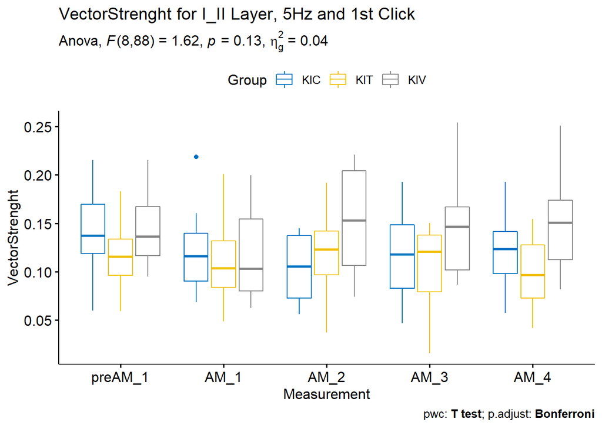

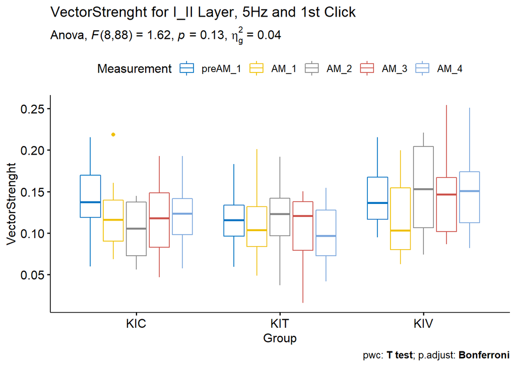

### IV Layer

#### VectorStrenght

##### Assumptions Check

**===OUTLIERS===**

| Group | Measurement | Animal | VectorStrenght | is.outlier | is.extreme |
| --- | --- | --- | --- | --- | --- |
| KIC | AM_2 | KIC12 | 0.032980 | TRUE | FALSE |
| KIC | AM_2 | KIC14 | 0.146552 | TRUE | FALSE |
| KIV | AM_2 | KIV09 | 0.031393 | TRUE | FALSE |
| KIT | AM_3 | KIT03 | 0.222633 | TRUE | FALSE |
| KIT | AM_3 | KIT04 | 0.031202 | TRUE | TRUE |
| KIC | AM_4 | KIC10 | 0.026913 | TRUE | TRUE |
| KIC | AM_4 | KIC11 | 0.087601 | TRUE | FALSE |

**===NORMALITY ASSUMPTION===**

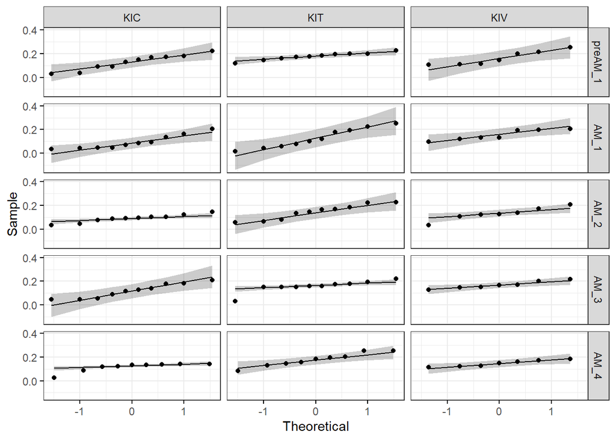

**===HOMOGENEITY OF VARIANCE ASSUMPTION===**

| Measurement | df1 | df2 | statistic | p |
| --- | --- | --- | --- | --- |
| preAM_1 | 2 | 24 | 2.363 | 0.116 |
| AM_1 | 2 | 24 | 1.599 | 0.223 |
| AM_2 | 2 | 24 | 1.503 | 0.243 |
| AM_3 | 2 | 24 | 1.527 | 0.238 |
| AM_4 | 2 | 22 | 1.592 | 0.226 |

##### Mixed ANOVA

Effect

DFn

DFd

F

p

p..05

ges

Group

2.00

22.00

7.760

0.003

0.210

Measurement

2.69

59.26

2.615

0.065

0.069

Group:Measurement

5.39

59.26

0.371

0.878

0.021

##### Post-hoc Tests

**===SIGNIFICANT TWO-WAY INTERACTION===**

**=EFFECT OF GROUP AT EACH MEASUREMENT=**

Measurement

Effect

DFn

DFd

p

p..05

ges

p.adj

preAM_1

Group

2

24

0.113

0.166

0.565

AM_1

Group

2

24

0.182

0.133

0.910

AM_2

Group

2

24

0.067

0.202

0.335

AM_3

Group

2

24

0.119

0.162

0.595

AM_4

Group

2

22

0.018

0.305

0.090

**=PAIRWISE COMPARISONS BETWEEN GROUP LEVELS=**

Measurement

.y.

group1

group2

n1

n2

statistic

df

p

p.adj

p.adj.signif

effsize

magnitude

preAM_1

VectorStrenght

KIC

KIT

10

10

-2.238

13.138

0.043

0.129

ns

-1.001

large

preAM_1

VectorStrenght

KIC

KIV

10

7

-1.181

13.695

0.258

0.774

ns

-0.578

moderate

preAM_1

VectorStrenght

KIT

KIV

10

7

0.604

8.395

0.562

1.000

ns

0.312

small

AM_1

VectorStrenght

KIC

KIT

10

10

-1.047

16.318

0.310

0.930

ns

-0.468

small

AM_1

VectorStrenght

KIC

KIV

10

7

-2.442

14.857

0.028

0.083

ns

-1.174

large

AM_1

VectorStrenght

KIT

KIV

10

7

-0.897

14.333

0.384

1.000

ns

-0.420

small

AM_2

VectorStrenght

KIC

KIT

10

10

-2.475

13.852

0.027

0.081

ns

-1.107

large

AM_2

VectorStrenght

KIC

KIV

10

7

-1.686

9.096

0.126

0.378

ns

-0.864

large

AM_2

VectorStrenght

KIT

KIV

10

7

0.549

13.998

0.592

1.000

ns

0.268

small

AM_3

VectorStrenght

KIC

KIT

10

10

-1.522

17.454

0.146

0.438

ns

-0.681

moderate

AM_3

VectorStrenght

KIC

KIV

10

7

-2.193

14.149

0.046

0.136

ns

-1.025

large

AM_3

VectorStrenght

KIT

KIV

10

7

-0.576

14.887

0.573

1.000

ns

-0.273

small

AM_4

VectorStrenght

KIC

KIT

9

9

-2.801

13.845

0.014

0.043

-1.320

large

AM_4

VectorStrenght

KIC

KIV

9

7

-1.983

13.951

0.067

0.202

ns

-0.979

large

AM_4

VectorStrenght

KIT

KIV

9

7

1.470

11.957

0.167

0.501

ns

0.711

moderate

**=EFFECT OF MEASUREMENT AT EACH LEVEL OF GROUP=**

| Group | Effect | DFn | DFd | F | p | p..05 | ges | p.adj |
| --- | --- | --- | --- | --- | --- | --- | --- | --- |
| KIC | Measurement | 1.87 | 14.95 | 0.653 | 0.525 |  | 0.068 | 1.000 |
| KIT | Measurement | 4.00 | 32.00 | 2.282 | 0.082 |  | 0.106 | 0.246 |
| KIV | Measurement | 1.64 | 9.86 | 1.437 | 0.278 |  | 0.098 | 0.834 |

**=PAIRWISE COMPARISONS BETWEEN MEASUREMENTS AT EACH GROUP LEVELS=**

| Group | .y. | group1 | group2 | n1 | n2 | statistic | df | p | p.adj | p.adj.signif | effsize | magnitude |
| --- | --- | --- | --- | --- | --- | --- | --- | --- | --- | --- | --- | --- |
| KIC | VectorStrenght | preAM_1 | AM_1 | 9 | 9 | 0.750 | 8 | 0.475 | 1.000 | ns | 0.250 | small |
| KIC | VectorStrenght | preAM_1 | AM_2 | 9 | 9 | 1.633 | 8 | 0.141 | 1.000 | ns | 0.544 | moderate |
| KIC | VectorStrenght | preAM_1 | AM_3 | 9 | 9 | 0.116 | 8 | 0.911 | 1.000 | ns | 0.039 | negligible |
| KIC | VectorStrenght | preAM_1 | AM_4 | 9 | 9 | 0.316 | 8 | 0.760 | 1.000 | ns | 0.105 | negligible |
| KIC | VectorStrenght | AM_1 | AM_2 | 9 | 9 | 0.477 | 8 | 0.646 | 1.000 | ns | 0.159 | negligible |
| KIC | VectorStrenght | AM_1 | AM_3 | 9 | 9 | -1.229 | 8 | 0.254 | 1.000 | ns | -0.410 | small |
| KIC | VectorStrenght | AM_1 | AM_4 | 9 | 9 | -0.664 | 8 | 0.525 | 1.000 | ns | -0.221 | small |
| KIC | VectorStrenght | AM_2 | AM_3 | 9 | 9 | -1.319 | 8 | 0.224 | 1.000 | ns | -0.440 | small |
| KIC | VectorStrenght | AM_2 | AM_4 | 9 | 9 | -1.354 | 8 | 0.213 | 1.000 | ns | -0.451 | small |
| KIC | VectorStrenght | AM_3 | AM_4 | 9 | 9 | 0.233 | 8 | 0.822 | 1.000 | ns | 0.078 | negligible |
| KIT | VectorStrenght | preAM_1 | AM_1 | 9 | 9 | 1.930 | 8 | 0.090 | 0.898 | ns | 0.643 | moderate |
| KIT | VectorStrenght | preAM_1 | AM_2 | 9 | 9 | 1.934 | 8 | 0.089 | 0.892 | ns | 0.645 | moderate |
| KIT | VectorStrenght | preAM_1 | AM_3 | 9 | 9 | 1.566 | 8 | 0.156 | 1.000 | ns | 0.522 | moderate |
| KIT | VectorStrenght | preAM_1 | AM_4 | 9 | 9 | 0.437 | 8 | 0.673 | 1.000 | ns | 0.146 | negligible |
| KIT | VectorStrenght | AM_1 | AM_2 | 9 | 9 | -1.060 | 8 | 0.320 | 1.000 | ns | -0.353 | small |
| KIT | VectorStrenght | AM_1 | AM_3 | 9 | 9 | -1.358 | 8 | 0.211 | 1.000 | ns | -0.453 | small |
| KIT | VectorStrenght | AM_1 | AM_4 | 9 | 9 | -1.643 | 8 | 0.139 | 1.000 | ns | -0.548 | moderate |
| KIT | VectorStrenght | AM_2 | AM_3 | 9 | 9 | -1.088 | 8 | 0.308 | 1.000 | ns | -0.363 | small |
| KIT | VectorStrenght | AM_2 | AM_4 | 9 | 9 | -1.857 | 8 | 0.100 | 1.000 | ns | -0.619 | moderate |
| KIT | VectorStrenght | AM_3 | AM_4 | 9 | 9 | -0.489 | 8 | 0.638 | 1.000 | ns | -0.163 | negligible |
| KIV | VectorStrenght | preAM_1 | AM_1 | 7 | 7 | 0.905 | 6 | 0.400 | 1.000 | ns | 0.342 | small |
| KIV | VectorStrenght | preAM_1 | AM_2 | 7 | 7 | 1.593 | 6 | 0.162 | 1.000 | ns | 0.602 | moderate |
| KIV | VectorStrenght | preAM_1 | AM_3 | 7 | 7 | -0.209 | 6 | 0.842 | 1.000 | ns | -0.079 | negligible |
| KIV | VectorStrenght | preAM_1 | AM_4 | 7 | 7 | 0.642 | 6 | 0.545 | 1.000 | ns | 0.242 | small |
| KIV | VectorStrenght | AM_1 | AM_2 | 7 | 7 | 1.877 | 6 | 0.110 | 1.000 | ns | 0.709 | moderate |
| KIV | VectorStrenght | AM_1 | AM_3 | 7 | 7 | -0.789 | 6 | 0.460 | 1.000 | ns | -0.298 | small |
| KIV | VectorStrenght | AM_1 | AM_4 | 7 | 7 | 0.414 | 6 | 0.693 | 1.000 | ns | 0.157 | negligible |
| KIV | VectorStrenght | AM_2 | AM_3 | 7 | 7 | -2.401 | 6 | 0.053 | 0.532 | ns | -0.907 | large |
| KIV | VectorStrenght | AM_2 | AM_4 | 7 | 7 | -1.113 | 6 | 0.308 | 1.000 | ns | -0.421 | small |
| KIV | VectorStrenght | AM_3 | AM_4 | 7 | 7 | 2.877 | 6 | 0.028 | 0.282 | ns | 1.087 | large |

**===NON-SIGNIFICANT TWO-WAY INTERACTION===**

**=MAIN EFFECT OF MEASUREMENT=**

| .y. | group1 | group2 | n1 | n2 | statistic | df | p | p.adj | p.adj.signif |
| --- | --- | --- | --- | --- | --- | --- | --- | --- | --- |
| VectorStrenght | preAM_1 | AM_1 | 25 | 25 | 1.8648681 | 24 | 0.074 | 0.745 | ns |
| VectorStrenght | preAM_1 | AM_2 | 25 | 25 | 3.0420570 | 24 | 0.006 | 0.056 | ns |
| VectorStrenght | preAM_1 | AM_3 | 25 | 25 | 0.2945440 | 24 | 0.771 | 1.000 | ns |
| VectorStrenght | preAM_1 | AM_4 | 25 | 25 | 0.7576979 | 24 | 0.456 | 1.000 | ns |
| VectorStrenght | AM_1 | AM_2 | 25 | 25 | 0.4254897 | 24 | 0.674 | 1.000 | ns |
| VectorStrenght | AM_1 | AM_3 | 25 | 25 | -2.0526719 | 24 | 0.051 | 0.512 | ns |
| VectorStrenght | AM_1 | AM_4 | 25 | 25 | -1.3757172 | 24 | 0.182 | 1.000 | ns |
| VectorStrenght | AM_2 | AM_3 | 25 | 25 | -2.6017900 | 24 | 0.016 | 0.156 | ns |
| VectorStrenght | AM_2 | AM_4 | 25 | 25 | -2.5163565 | 24 | 0.019 | 0.190 | ns |
| VectorStrenght | AM_3 | AM_4 | 25 | 25 | 0.5818454 | 24 | 0.566 | 1.000 | ns |

**=MAIN EFFECT OF GROUP=**

| .y. | group1 | group2 | n1 | n2 | p | p.signif | p.adj | p.adj.signif |
| --- | --- | --- | --- | --- | --- | --- | --- | --- |
| VectorStrenght | KIC | KIT | 49 | 49 | 2.18e-05 | **** | 6.55e-05 | **** |
| VectorStrenght | KIC | KIV | 49 | 35 | 3.49e-04 | *** | 1.05e-03 | ** |
| VectorStrenght | KIT | KIV | 49 | 35 | 7.28e-01 | ns | 1.00e+00 | ns |

##### Plots

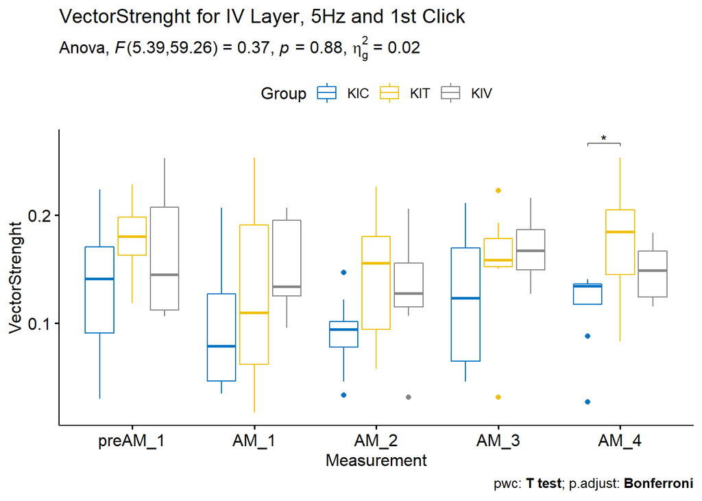

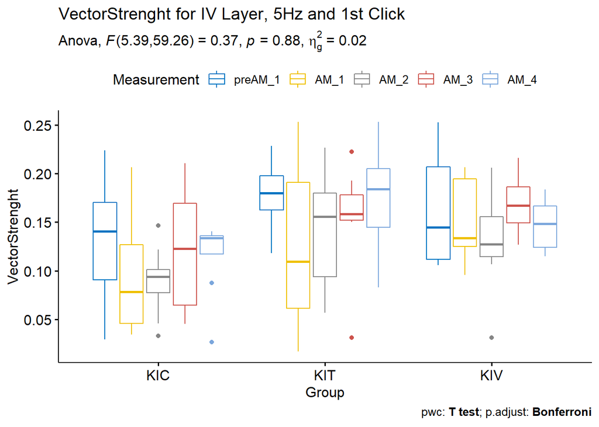

### V Layer

#### VectorStrenght

##### Assumptions Check

**===OUTLIERS===**

| Group | Measurement | Animal | VectorStrenght | is.outlier | is.extreme |
| --- | --- | --- | --- | --- | --- |
| KIC | AM_2 | KIC10 | 0.199569 | TRUE | FALSE |
| KIT | AM_2 | KIT07 | 0.238872 | TRUE | FALSE |
| KIV | AM_2 | KIV09 | 0.026778 | TRUE | FALSE |

**===NORMALITY ASSUMPTION===**

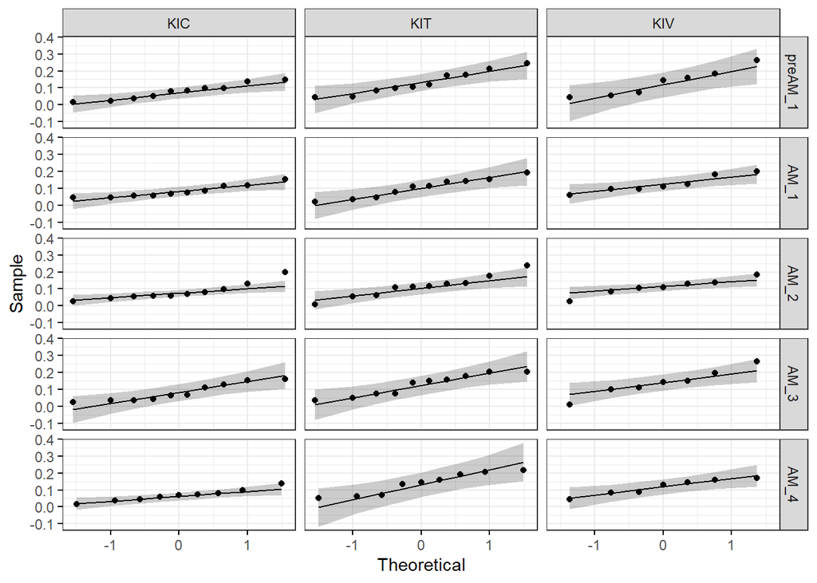

**===HOMOGENEITY OF VARIANCE ASSUMPTION===**

| Measurement | df1 | df2 | statistic | p |
| --- | --- | --- | --- | --- |
| preAM_1 | 2 | 24 | 1.214 | 0.315 |
| AM_1 | 2 | 24 | 0.864 | 0.434 |
| AM_2 | 2 | 24 | 0.257 | 0.775 |
| AM_3 | 2 | 24 | 0.279 | 0.759 |
| AM_4 | 2 | 22 | 1.649 | 0.215 |

##### Mixed ANOVA

| Effect | DFn | DFd | F | p | p..05 | ges |
| --- | --- | --- | --- | --- | --- | --- |
| Group | 2 | 22 | 2.919 | 0.075 |  | 0.146 |
| Measurement | 4 | 88 | 1.032 | 0.395 |  | 0.016 |
| Group:Measurement | 8 | 88 | 0.780 | 0.622 |  | 0.024 |

##### Post-hoc Tests

**===SIGNIFICANT TWO-WAY INTERACTION===**

**=EFFECT OF GROUP AT EACH MEASUREMENT=**

Measurement

Effect

DFn

DFd

p

p..05

ges

p.adj

preAM_1

Group

2

24

0.126

0.158

0.63

AM_1

Group

2

24

0.224

0.117

1.00

AM_2

Group

2

24

0.390

0.076

1.00

AM_3

Group

2

24

0.158

0.143

0.79

AM_4

Group

2

22

0.024

0.289

0.12

**=PAIRWISE COMPARISONS BETWEEN GROUP LEVELS=**

Measurement

.y.

group1

group2

n1

n2

statistic

df

p

p.adj

p.adj.signif

effsize

magnitude

preAM_1

VectorStrenght

KIC

KIT

10

10

-2.082

15.616

0.054

0.163

ns

-0.931

large

preAM_1

VectorStrenght

KIC

KIV

10

7

-1.642

8.716

0.136

0.408

ns

-0.845

large

preAM_1

VectorStrenght

KIT

KIV

10

7

-0.022

11.700

0.983

1.000

ns

-0.011

negligible

AM_1

VectorStrenght

KIC

KIT

10

10

-1.021

15.192

0.323

0.969

ns

-0.456

small

AM_1

VectorStrenght

KIC

KIV

10

7

-1.887

10.046

0.088

0.265

ns

-0.958

large

AM_1

VectorStrenght

KIT

KIV

10

7

-0.781

13.915

0.448

1.000

ns

-0.382

small

AM_2

VectorStrenght

KIC

KIT

10

10

-1.244

17.016

0.230

0.690

ns

-0.556

moderate

AM_2

VectorStrenght

KIC

KIV

10

7

-1.203

13.372

0.250

0.750

ns

-0.591

moderate

AM_2

VectorStrenght

KIT

KIV

10

7

0.106

14.852

0.917

1.000

ns

0.051

negligible

AM_3

VectorStrenght

KIC

KIT

10

10

-1.716

17.339

0.104

0.312

ns

-0.767

moderate

AM_3

VectorStrenght

KIC

KIV

10

7

-1.679

9.512

0.126

0.378

ns

-0.857

large

AM_3

VectorStrenght

KIT

KIV

10

7

-0.368

11.004

0.720

1.000

ns

-0.185

negligible

AM_4

VectorStrenght

KIC

KIT

9

9

-2.842

12.730

0.014

0.042

-1.340

large

AM_4

VectorStrenght

KIC

KIV

9

7

-2.287

11.184

0.043

0.128

ns

-1.170

large

AM_4

VectorStrenght

KIT

KIV

9

7

0.748

13.973

0.467

1.000

ns

0.370

small

**=EFFECT OF MEASUREMENT AT EACH LEVEL OF GROUP=**

| Group | Effect | DFn | DFd | F | p | p..05 | ges | p.adj |
| --- | --- | --- | --- | --- | --- | --- | --- | --- |
| KIC | Measurement | 4.00 | 32.00 | 0.341 | 0.848 |  | 0.026 | 1.000 |
| KIT | Measurement | 1.73 | 13.85 | 1.501 | 0.255 |  | 0.055 | 0.765 |
| KIV | Measurement | 4.00 | 24.00 | 0.810 | 0.531 |  | 0.030 | 1.000 |

**=PAIRWISE COMPARISONS BETWEEN MEASUREMENTS AT EACH GROUP LEVELS=**

| Group | .y. | group1 | group2 | n1 | n2 | statistic | df | p | p.adj | p.adj.signif | effsize | magnitude |
| --- | --- | --- | --- | --- | --- | --- | --- | --- | --- | --- | --- | --- |
| KIC | VectorStrenght | preAM_1 | AM_1 | 9 | 9 | -0.152 | 8 | 0.883 | 1.000 | ns | -0.051 | negligible |
| KIC | VectorStrenght | preAM_1 | AM_2 | 9 | 9 | -0.083 | 8 | 0.936 | 1.000 | ns | -0.028 | negligible |
| KIC | VectorStrenght | preAM_1 | AM_3 | 9 | 9 | -0.249 | 8 | 0.810 | 1.000 | ns | -0.083 | negligible |
| KIC | VectorStrenght | preAM_1 | AM_4 | 9 | 9 | 0.792 | 8 | 0.451 | 1.000 | ns | 0.264 | small |
| KIC | VectorStrenght | AM_1 | AM_2 | 9 | 9 | 0.047 | 8 | 0.964 | 1.000 | ns | 0.016 | negligible |
| KIC | VectorStrenght | AM_1 | AM_3 | 9 | 9 | -0.138 | 8 | 0.894 | 1.000 | ns | -0.046 | negligible |
| KIC | VectorStrenght | AM_1 | AM_4 | 9 | 9 | 0.970 | 8 | 0.360 | 1.000 | ns | 0.323 | small |
| KIC | VectorStrenght | AM_2 | AM_3 | 9 | 9 | -0.140 | 8 | 0.892 | 1.000 | ns | -0.047 | negligible |
| KIC | VectorStrenght | AM_2 | AM_4 | 9 | 9 | 0.734 | 8 | 0.484 | 1.000 | ns | 0.245 | small |
| KIC | VectorStrenght | AM_3 | AM_4 | 9 | 9 | 0.874 | 8 | 0.408 | 1.000 | ns | 0.291 | small |
| KIT | VectorStrenght | preAM_1 | AM_1 | 9 | 9 | 1.366 | 8 | 0.209 | 1.000 | ns | 0.455 | small |
| KIT | VectorStrenght | preAM_1 | AM_2 | 9 | 9 | 0.579 | 8 | 0.579 | 1.000 | ns | 0.193 | negligible |
| KIT | VectorStrenght | preAM_1 | AM_3 | 9 | 9 | 0.188 | 8 | 0.855 | 1.000 | ns | 0.063 | negligible |
| KIT | VectorStrenght | preAM_1 | AM_4 | 9 | 9 | 0.194 | 8 | 0.851 | 1.000 | ns | 0.065 | negligible |
| KIT | VectorStrenght | AM_1 | AM_2 | 9 | 9 | -1.780 | 8 | 0.113 | 1.000 | ns | -0.593 | moderate |
| KIT | VectorStrenght | AM_1 | AM_3 | 9 | 9 | -3.020 | 8 | 0.017 | 0.166 | ns | -1.007 | large |
| KIT | VectorStrenght | AM_1 | AM_4 | 9 | 9 | -2.067 | 8 | 0.073 | 0.726 | ns | -0.689 | moderate |
| KIT | VectorStrenght | AM_2 | AM_3 | 9 | 9 | -0.994 | 8 | 0.349 | 1.000 | ns | -0.331 | small |
| KIT | VectorStrenght | AM_2 | AM_4 | 9 | 9 | -0.626 | 8 | 0.549 | 1.000 | ns | -0.209 | small |
| KIT | VectorStrenght | AM_3 | AM_4 | 9 | 9 | -0.064 | 8 | 0.951 | 1.000 | ns | -0.021 | negligible |
| KIV | VectorStrenght | preAM_1 | AM_1 | 7 | 7 | 0.328 | 6 | 0.754 | 1.000 | ns | 0.124 | negligible |
| KIV | VectorStrenght | preAM_1 | AM_2 | 7 | 7 | 1.349 | 6 | 0.226 | 1.000 | ns | 0.510 | moderate |
| KIV | VectorStrenght | preAM_1 | AM_3 | 7 | 7 | -0.405 | 6 | 0.699 | 1.000 | ns | -0.153 | negligible |
| KIV | VectorStrenght | preAM_1 | AM_4 | 7 | 7 | 0.597 | 6 | 0.572 | 1.000 | ns | 0.226 | small |
| KIV | VectorStrenght | AM_1 | AM_2 | 7 | 7 | 0.854 | 6 | 0.426 | 1.000 | ns | 0.323 | small |
| KIV | VectorStrenght | AM_1 | AM_3 | 7 | 7 | -0.961 | 6 | 0.374 | 1.000 | ns | -0.363 | small |
| KIV | VectorStrenght | AM_1 | AM_4 | 7 | 7 | 0.550 | 6 | 0.602 | 1.000 | ns | 0.208 | small |
| KIV | VectorStrenght | AM_2 | AM_3 | 7 | 7 | -1.580 | 6 | 0.165 | 1.000 | ns | -0.597 | moderate |
| KIV | VectorStrenght | AM_2 | AM_4 | 7 | 7 | -0.381 | 6 | 0.716 | 1.000 | ns | -0.144 | negligible |
| KIV | VectorStrenght | AM_3 | AM_4 | 7 | 7 | 1.479 | 6 | 0.190 | 1.000 | ns | 0.559 | moderate |

**===NON-SIGNIFICANT TWO-WAY INTERACTION===**

**=MAIN EFFECT OF MEASUREMENT=**

| .y. | group1 | group2 | n1 | n2 | statistic | df | p | p.adj | p.adj.signif |
| --- | --- | --- | --- | --- | --- | --- | --- | --- | --- |
| VectorStrenght | preAM_1 | AM_1 | 25 | 25 | 1.1668341 | 24 | 0.255 | 1.000 | ns |
| VectorStrenght | preAM_1 | AM_2 | 25 | 25 | 0.9116376 | 24 | 0.371 | 1.000 | ns |
| VectorStrenght | preAM_1 | AM_3 | 25 | 25 | -0.2456774 | 24 | 0.808 | 1.000 | ns |
| VectorStrenght | preAM_1 | AM_4 | 25 | 25 | 0.9859975 | 24 | 0.334 | 1.000 | ns |
| VectorStrenght | AM_1 | AM_2 | 25 | 25 | -0.5110671 | 24 | 0.614 | 1.000 | ns |
| VectorStrenght | AM_1 | AM_3 | 25 | 25 | -1.9598440 | 24 | 0.062 | 0.617 | ns |
| VectorStrenght | AM_1 | AM_4 | 25 | 25 | -0.4141628 | 24 | 0.682 | 1.000 | ns |
| VectorStrenght | AM_2 | AM_3 | 25 | 25 | -1.2992898 | 24 | 0.206 | 1.000 | ns |
| VectorStrenght | AM_2 | AM_4 | 25 | 25 | 0.0046150 | 24 | 0.996 | 1.000 | ns |
| VectorStrenght | AM_3 | AM_4 | 25 | 25 | 1.3467361 | 24 | 0.191 | 1.000 | ns |

**=MAIN EFFECT OF GROUP=**

| .y. | group1 | group2 | n1 | n2 | p | p.signif | p.adj | p.adj.signif |
| --- | --- | --- | --- | --- | --- | --- | --- | --- |
| VectorStrenght | KIC | KIT | 49 | 49 | 0.000139 | *** | 0.000416 | *** |
| VectorStrenght | KIC | KIV | 49 | 35 | 0.000226 | *** | 0.000678 | *** |
| VectorStrenght | KIT | KIV | 49 | 35 | 0.835000 | ns | 1.000000 | ns |

##### Plots

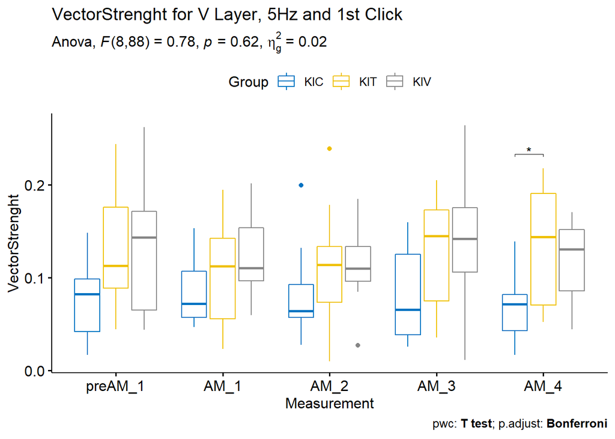

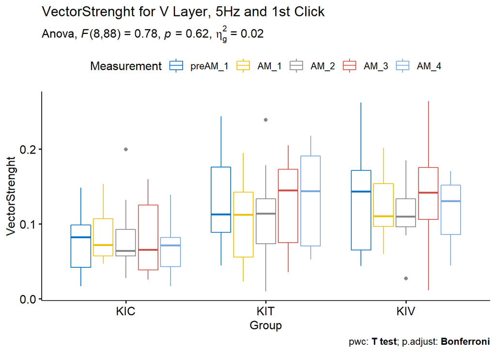

### VI Layer

#### VectorStrenght

##### Assumptions Check

**===OUTLIERS===**

| Group | Measurement | Animal | VectorStrenght | is.outlier | is.extreme |
| --- | --- | --- | --- | --- | --- |
| KIC | preAM_1 | KIC15 | 0.235927 | TRUE | FALSE |
| KIC | AM_1 | KIC15 | 0.246407 | TRUE | FALSE |
| KIC | AM_2 | KIC15 | 0.247202 | TRUE | TRUE |
| KIC | AM_3 | KIC15 | 0.242453 | TRUE | FALSE |

**===NORMALITY ASSUMPTION===**

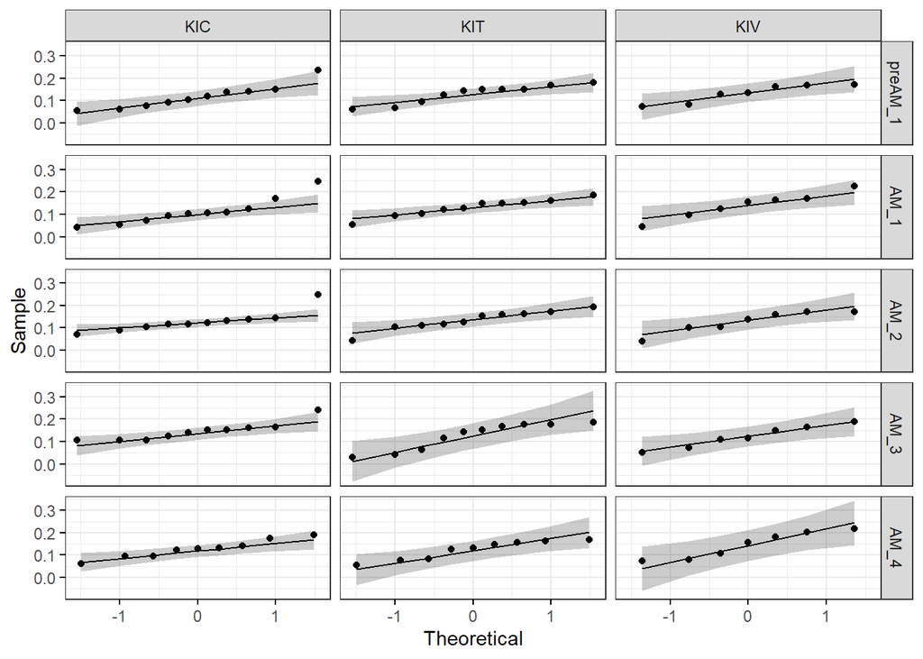

**===HOMOGENEITY OF VARIANCE ASSUMPTION===**

| Measurement | df1 | df2 | statistic | p |
| --- | --- | --- | --- | --- |
| preAM_1 | 2 | 24 | 0.214 | 0.808 |
| AM_1 | 2 | 24 | 0.284 | 0.755 |
| AM_2 | 2 | 24 | 0.152 | 0.860 |
| AM_3 | 2 | 24 | 0.729 | 0.493 |
| AM_4 | 2 | 22 | 1.294 | 0.294 |

##### Mixed ANOVA

| Effect | DFn | DFd | F | p | p..05 | ges |
| --- | --- | --- | --- | --- | --- | --- |
| Group | 2 | 22 | 0.578 | 0.570 |  | 0.029 |
| Measurement | 4 | 88 | 0.387 | 0.817 |  | 0.008 |
| Group:Measurement | 8 | 88 | 1.254 | 0.278 |  | 0.047 |

##### Post-hoc Tests

**===SIGNIFICANT TWO-WAY INTERACTION===**

**=EFFECT OF GROUP AT EACH MEASUREMENT=**

| Measurement | Effect | DFn | DFd | p | p..05 | ges | p.adj |
| --- | --- | --- | --- | --- | --- | --- | --- |
| preAM_1 | Group | 2 | 24 | 0.772 |  | 0.021 | 1 |
| AM_1 | Group | 2 | 24 | 0.527 |  | 0.052 | 1 |
| AM_2 | Group | 2 | 24 | 0.936 |  | 0.006 | 1 |
| AM_3 | Group | 2 | 24 | 0.553 |  | 0.048 | 1 |
| AM_4 | Group | 2 | 22 | 0.609 |  | 0.044 | 1 |

**=PAIRWISE COMPARISONS BETWEEN GROUP LEVELS=**

| Measurement | .y. | group1 | group2 | n1 | n2 | statistic | df | p | p.adj | p.adj.signif | effsize | magnitude |
| --- | --- | --- | --- | --- | --- | --- | --- | --- | --- | --- | --- | --- |
| preAM_1 | VectorStrenght | KIC | KIT | 10 | 10 | -0.564 | 17.021 | 0.580 | 1.0 | ns | -0.252 | small |
| preAM_1 | VectorStrenght | KIC | KIV | 10 | 7 | -0.642 | 14.846 | 0.531 | 1.0 | ns | -0.309 | small |
| preAM_1 | VectorStrenght | KIT | KIV | 10 | 7 | -0.125 | 13.362 | 0.903 | 1.0 | ns | -0.061 | negligible |
| AM_1 | VectorStrenght | KIC | KIT | 10 | 10 | -0.795 | 15.330 | 0.439 | 1.0 | ns | -0.356 | small |
| AM_1 | VectorStrenght | KIC | KIV | 10 | 7 | -0.988 | 13.349 | 0.341 | 1.0 | ns | -0.486 | small |
| AM_1 | VectorStrenght | KIT | KIV | 10 | 7 | -0.428 | 9.646 | 0.678 | 1.0 | ns | -0.218 | small |
| AM_2 | VectorStrenght | KIC | KIT | 10 | 10 | -0.297 | 17.852 | 0.770 | 1.0 | ns | -0.133 | negligible |
| AM_2 | VectorStrenght | KIC | KIV | 10 | 7 | 0.061 | 12.831 | 0.953 | 1.0 | ns | 0.030 | negligible |
| AM_2 | VectorStrenght | KIT | KIV | 10 | 7 | 0.325 | 12.013 | 0.750 | 1.0 | ns | 0.162 | negligible |
| AM_3 | VectorStrenght | KIC | KIT | 10 | 10 | 0.877 | 15.974 | 0.393 | 1.0 | ns | 0.392 | small |
| AM_3 | VectorStrenght | KIC | KIV | 10 | 7 | 1.085 | 11.400 | 0.300 | 0.9 | ns | 0.544 | moderate |
| AM_3 | VectorStrenght | KIT | KIV | 10 | 7 | 0.175 | 14.436 | 0.863 | 1.0 | ns | 0.085 | negligible |
| AM_4 | VectorStrenght | KIC | KIT | 9 | 9 | 0.189 | 15.968 | 0.853 | 1.0 | ns | 0.089 | negligible |
| AM_4 | VectorStrenght | KIC | KIV | 9 | 7 | -0.721 | 10.008 | 0.487 | 1.0 | ns | -0.372 | small |
| AM_4 | VectorStrenght | KIT | KIV | 9 | 7 | -0.850 | 10.329 | 0.415 | 1.0 | ns | -0.437 | small |

**=EFFECT OF MEASUREMENT AT EACH LEVEL OF GROUP=**

| Group | Effect | DFn | DFd | F | p | p..05 | ges | p.adj |
| --- | --- | --- | --- | --- | --- | --- | --- | --- |
| KIC | Measurement | 4 | 32 | 2.618 | 0.053 |  | 0.163 | 0.159 |
| KIT | Measurement | 4 | 32 | 0.186 | 0.944 |  | 0.010 | 1.000 |
| KIV | Measurement | 4 | 24 | 0.565 | 0.690 |  | 0.033 | 1.000 |

**=PAIRWISE COMPARISONS BETWEEN MEASUREMENTS AT EACH GROUP LEVELS=**

| Group | .y. | group1 | group2 | n1 | n2 | statistic | df | p | p.adj | p.adj.signif | effsize | magnitude |
| --- | --- | --- | --- | --- | --- | --- | --- | --- | --- | --- | --- | --- |
| KIC | VectorStrenght | preAM_1 | AM_1 | 9 | 9 | 0.423 | 8 | 0.684 | 1.000 | ns | 0.141 | negligible |
| KIC | VectorStrenght | preAM_1 | AM_2 | 9 | 9 | -0.705 | 8 | 0.501 | 1.000 | ns | -0.235 | small |
| KIC | VectorStrenght | preAM_1 | AM_3 | 9 | 9 | -1.780 | 8 | 0.113 | 1.000 | ns | -0.593 | moderate |
| KIC | VectorStrenght | preAM_1 | AM_4 | 9 | 9 | -1.253 | 8 | 0.246 | 1.000 | ns | -0.418 | small |
| KIC | VectorStrenght | AM_1 | AM_2 | 9 | 9 | -1.797 | 8 | 0.110 | 1.000 | ns | -0.599 | moderate |
| KIC | VectorStrenght | AM_1 | AM_3 | 9 | 9 | -2.718 | 8 | 0.026 | 0.263 | ns | -0.906 | large |
| KIC | VectorStrenght | AM_1 | AM_4 | 9 | 9 | -2.426 | 8 | 0.042 | 0.415 | ns | -0.809 | large |
| KIC | VectorStrenght | AM_2 | AM_3 | 9 | 9 | -2.965 | 8 | 0.018 | 0.180 | ns | -0.988 | large |
| KIC | VectorStrenght | AM_2 | AM_4 | 9 | 9 | -1.173 | 8 | 0.275 | 1.000 | ns | -0.391 | small |
| KIC | VectorStrenght | AM_3 | AM_4 | 9 | 9 | 0.806 | 8 | 0.444 | 1.000 | ns | 0.269 | small |
| KIT | VectorStrenght | preAM_1 | AM_1 | 9 | 9 | -0.025 | 8 | 0.980 | 1.000 | ns | -0.008 | negligible |
| KIT | VectorStrenght | preAM_1 | AM_2 | 9 | 9 | -0.317 | 8 | 0.759 | 1.000 | ns | -0.106 | negligible |
| KIT | VectorStrenght | preAM_1 | AM_3 | 9 | 9 | 0.345 | 8 | 0.739 | 1.000 | ns | 0.115 | negligible |
| KIT | VectorStrenght | preAM_1 | AM_4 | 9 | 9 | 0.383 | 8 | 0.712 | 1.000 | ns | 0.128 | negligible |
| KIT | VectorStrenght | AM_1 | AM_2 | 9 | 9 | -0.371 | 8 | 0.721 | 1.000 | ns | -0.124 | negligible |
| KIT | VectorStrenght | AM_1 | AM_3 | 9 | 9 | 0.428 | 8 | 0.680 | 1.000 | ns | 0.143 | negligible |
| KIT | VectorStrenght | AM_1 | AM_4 | 9 | 9 | 0.481 | 8 | 0.643 | 1.000 | ns | 0.160 | negligible |
| KIT | VectorStrenght | AM_2 | AM_3 | 9 | 9 | 0.687 | 8 | 0.512 | 1.000 | ns | 0.229 | small |
| KIT | VectorStrenght | AM_2 | AM_4 | 9 | 9 | 0.884 | 8 | 0.403 | 1.000 | ns | 0.295 | small |
| KIT | VectorStrenght | AM_3 | AM_4 | 9 | 9 | -0.156 | 8 | 0.880 | 1.000 | ns | -0.052 | negligible |
| KIV | VectorStrenght | preAM_1 | AM_1 | 7 | 7 | -0.359 | 6 | 0.732 | 1.000 | ns | -0.136 | negligible |
| KIV | VectorStrenght | preAM_1 | AM_2 | 7 | 7 | 0.343 | 6 | 0.743 | 1.000 | ns | 0.130 | negligible |
| KIV | VectorStrenght | preAM_1 | AM_3 | 7 | 7 | 0.641 | 6 | 0.545 | 1.000 | ns | 0.242 | small |
| KIV | VectorStrenght | preAM_1 | AM_4 | 7 | 7 | -0.485 | 6 | 0.645 | 1.000 | ns | -0.183 | negligible |
| KIV | VectorStrenght | AM_1 | AM_2 | 7 | 7 | 1.305 | 6 | 0.240 | 1.000 | ns | 0.493 | small |
| KIV | VectorStrenght | AM_1 | AM_3 | 7 | 7 | 1.209 | 6 | 0.272 | 1.000 | ns | 0.457 | small |
| KIV | VectorStrenght | AM_1 | AM_4 | 7 | 7 | -0.228 | 6 | 0.827 | 1.000 | ns | -0.086 | negligible |
| KIV | VectorStrenght | AM_2 | AM_3 | 7 | 7 | 0.429 | 6 | 0.683 | 1.000 | ns | 0.162 | negligible |
| KIV | VectorStrenght | AM_2 | AM_4 | 7 | 7 | -0.809 | 6 | 0.450 | 1.000 | ns | -0.306 | small |
| KIV | VectorStrenght | AM_3 | AM_4 | 7 | 7 | -1.923 | 6 | 0.103 | 1.000 | ns | -0.727 | moderate |

**===NON-SIGNIFICANT TWO-WAY INTERACTION===**

**=MAIN EFFECT OF MEASUREMENT=**

| .y. | group1 | group2 | n1 | n2 | statistic | df | p | p.adj | p.adj.signif |
| --- | --- | --- | --- | --- | --- | --- | --- | --- | --- |
| VectorStrenght | preAM_1 | AM_1 | 25 | 25 | 0.0145485 | 24 | 0.989 | 1 | ns |
| VectorStrenght | preAM_1 | AM_2 | 25 | 25 | -0.4844216 | 24 | 0.632 | 1 | ns |
| VectorStrenght | preAM_1 | AM_3 | 25 | 25 | -0.4344934 | 24 | 0.668 | 1 | ns |
| VectorStrenght | preAM_1 | AM_4 | 25 | 25 | -0.9438028 | 24 | 0.355 | 1 | ns |
| VectorStrenght | AM_1 | AM_2 | 25 | 25 | -0.6475828 | 24 | 0.523 | 1 | ns |
| VectorStrenght | AM_1 | AM_3 | 25 | 25 | -0.4882597 | 24 | 0.630 | 1 | ns |
| VectorStrenght | AM_1 | AM_4 | 25 | 25 | -1.2240006 | 24 | 0.233 | 1 | ns |
| VectorStrenght | AM_2 | AM_3 | 25 | 25 | -0.0980963 | 24 | 0.923 | 1 | ns |
| VectorStrenght | AM_2 | AM_4 | 25 | 25 | -0.7069281 | 24 | 0.486 | 1 | ns |
| VectorStrenght | AM_3 | AM_4 | 25 | 25 | -0.5595418 | 24 | 0.581 | 1 | ns |

**=MAIN EFFECT OF GROUP=**

| .y. | group1 | group2 | n1 | n2 | p | p.signif | p.adj | p.adj.signif |
| --- | --- | --- | --- | --- | --- | --- | --- | --- |
| VectorStrenght | KIC | KIT | 49 | 49 | 0.787 | ns | 1 | ns |
| VectorStrenght | KIC | KIV | 49 | 35 | 0.492 | ns | 1 | ns |
| VectorStrenght | KIT | KIV | 49 | 35 | 0.660 | ns | 1 | ns |

##### Plots

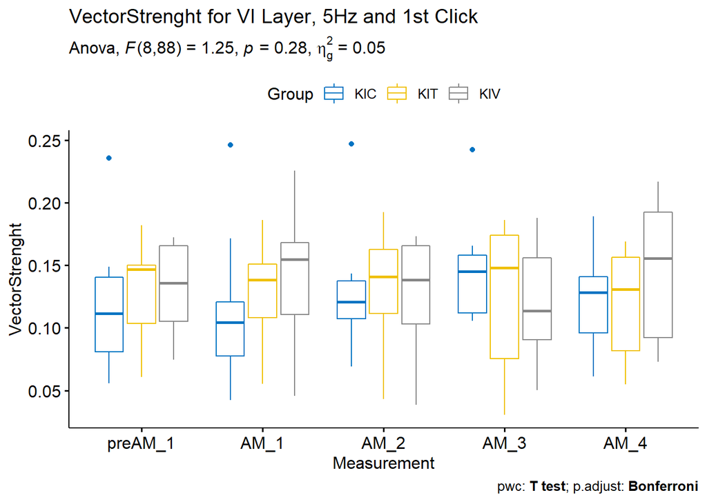

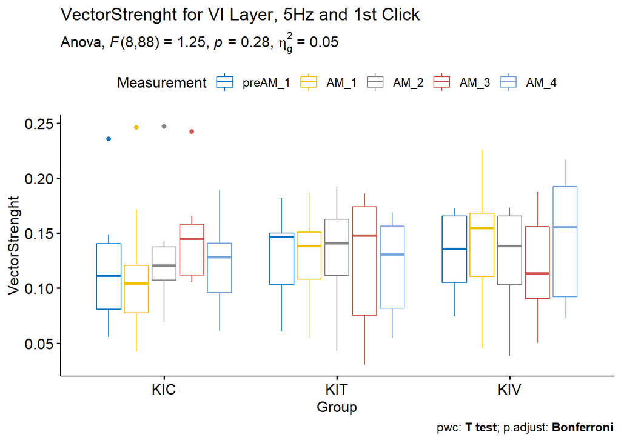